# Deliverable 3

Kyle Kirk

We will work on the third deliverable, but to do so we need to bring in everything from the first and second. We can do this in the same fashion that we did in the previous deliverable by incorporating everything from the second.

| FIPS | State | Area_name | Civilian_labor_force_2007 | Employed_2007 | Unemployed_2007 | Unemployment_rate_2007 | year |
| --- | --- | --- | --- | --- | --- | --- | --- |
| 0 | US | United States | 152191093 | 145156134 | 7034959 | 4.6 | 2007 |
| 1000 | AL | Alabama | 2175612 | 2089127 | 86485 | 4.0 | 2007 |
| 1001 | AL | Autauga County, AL | 24383 | 23577 | 806 | 3.3 | 2007 |
| 1003 | AL | Baldwin County, AL | 82659 | 80099 | 2560 | 3.1 | 2007 |
| 1005 | AL | Barbour County, AL | 10334 | 9684 | 650 | 6.3 | 2007 |
| 1007 | AL | Bibb County, AL | 8791 | 8432 | 359 | 4.1 | 2007 |
| 1009 | AL | Blount County, AL | 26629 | 25780 | 849 | 3.2 | 2007 |
| 1011 | AL | Bullock County, AL | 3653 | 3308 | 345 | 9.4 | 2007 |
| 1013 | AL | Butler County, AL | 9099 | 8539 | 560 | 6.2 | 2007 |
| 1015 | AL | Calhoun County, AL | 54861 | 52709 | 2152 | 3.9 | 2007 |

[output cut: 990 more lines]

| FIPS | state | county | civilian_labor | employed | unemployed | unemployment_rate | year |
| --- | --- | --- | --- | --- | --- | --- | --- |
| 0 | US | United States | 152191093 | 145156134 | 7034959 | 4.6 | 2007 |
| 1000 | AL | Alabama | 2175612 | 2089127 | 86485 | 4.0 | 2007 |
| 1001 | AL | Autauga County, AL | 24383 | 23577 | 806 | 3.3 | 2007 |
| 1003 | AL | Baldwin County, AL | 82659 | 80099 | 2560 | 3.1 | 2007 |
| 1005 | AL | Barbour County, AL | 10334 | 9684 | 650 | 6.3 | 2007 |
| 1007 | AL | Bibb County, AL | 8791 | 8432 | 359 | 4.1 | 2007 |
| 1009 | AL | Blount County, AL | 26629 | 25780 | 849 | 3.2 | 2007 |
| 1011 | AL | Bullock County, AL | 3653 | 3308 | 345 | 9.4 | 2007 |
| 1013 | AL | Butler County, AL | 9099 | 8539 | 560 | 6.2 | 2007 |
| 1015 | AL | Calhoun County, AL | 54861 | 52709 | 2152 | 3.9 | 2007 |

[output cut: 990 more lines]

| FIPS | state | county | civilian_labor | employed | unemployed | unemployment_rate | year |
| --- | --- | --- | --- | --- | --- | --- | --- |
| 0 | US | United States | 152191093 | 145156134 | 7034959 | 4.6 | 2007 |
| 1000 | AL | Alabama | 2175612 | 2089127 | 86485 | 4.0 | 2007 |
| 1001 | AL | Autauga County, AL | 24383 | 23577 | 806 | 3.3 | 2007 |
| 1003 | AL | Baldwin County, AL | 82659 | 80099 | 2560 | 3.1 | 2007 |
| 1005 | AL | Barbour County, AL | 10334 | 9684 | 650 | 6.3 | 2007 |
| 1007 | AL | Bibb County, AL | 8791 | 8432 | 359 | 4.1 | 2007 |
| 1009 | AL | Blount County, AL | 26629 | 25780 | 849 | 3.2 | 2007 |
| 1011 | AL | Bullock County, AL | 3653 | 3308 | 345 | 9.4 | 2007 |
| 1013 | AL | Butler County, AL | 9099 | 8539 | 560 | 6.2 | 2007 |
| 1015 | AL | Calhoun County, AL | 54861 | 52709 | 2152 | 3.9 | 2007 |

[output cut: 990 more lines]

| year | Deaths | Population | percent |
| --- | --- | --- | --- |
| 1999 | 19128 | 279040168 | 0.00006854927 |
| 2000 | 19720 | 281421906 | 0.00007007273 |
| 2001 | 21705 | 284968955 | 0.00007616619 |
| 2002 | 26040 | 287625193 | 0.00009053449 |
| 2003 | 28723 | 290107933 | 0.00009900798 |
| 2004 | 30711 | 292805298 | 0.00010488540 |
| 2005 | 33541 | 295516599 | 0.00011349955 |
| 2006 | 38396 | 298379912 | 0.00012868158 |
| 2007 | 38371 | 301231207 | 0.00012738056 |
| 2008 | 38649 | 304093966 | 0.00012709558 |

[output cut: 7 more lines]

| county | civilian_labor | employed | unemployed | unemployment_rate | year |
| --- | --- | --- | --- | --- | --- |
| United States | 152191093 | 145156134 | 7034959 | 4.60 | 2007 |
| United States | 153761095 | 144860350 | 8900745 | 5.80 | 2008 |
| United States | 153825455 | 139594698 | 14230757 | 9.30 | 2009 |
| United States | 154270732 | 139408204 | 14862528 | 9.63 | 2010 |
| United States | 154606316 | 140765809 | 13840507 | 8.95 | 2011 |
| United States | 155119195 | 142600402 | 12518793 | 8.07 | 2012 |
| United States | 155485692 | 144018151 | 11467541 | 7.38 | 2013 |
| United States | 155957297 | 146338305 | 9618992 | 6.17 | 2014 |
| United States | 156866585 | 148579026 | 8287559 | 5.28 | 2015 |
| United States | 158708795 | 150981151 | 7727644 | 4.87 | 2016 |

[output cut: 1 more lines]

| year | drug_related_deaths_number | Population | drug_related_deaths_percent |
| --- | --- | --- | --- |
| 1999 | 19128 | 279040168 | 0.00006854927 |
| 2000 | 19720 | 281421906 | 0.00007007273 |
| 2001 | 21705 | 284968955 | 0.00007616619 |
| 2002 | 26040 | 287625193 | 0.00009053449 |
| 2003 | 28723 | 290107933 | 0.00009900798 |
| 2004 | 30711 | 292805298 | 0.00010488540 |
| 2005 | 33541 | 295516599 | 0.00011349955 |
| 2006 | 38396 | 298379912 | 0.00012868158 |
| 2007 | 38371 | 301231207 | 0.00012738056 |
| 2008 | 38649 | 304093966 | 0.00012709558 |

[output cut: 7 more lines]

|  | year | drug_related_deaths_number | Population | drug_related_deaths_percent | county | civilian_labor | employed | unemployed | unemployment_rate |
| --- | --- | --- | --- | --- | --- | --- | --- | --- | --- |
| 9 | 2007 | 38371 | 301231207 | 0.0001273806 | United States | 152191093 | 145156134 | 7034959 | 4.60 |
| 10 | 2008 | 38649 | 304093966 | 0.0001270956 | United States | 153761095 | 144860350 | 8900745 | 5.80 |
| 11 | 2009 | 39147 | 306771529 | 0.0001276096 | United States | 153825455 | 139594698 | 14230757 | 9.30 |
| 12 | 2010 | 40393 | 308745538 | 0.0001308294 | United States | 154270732 | 139408204 | 14862528 | 9.63 |
| 13 | 2011 | 43544 | 311591917 | 0.0001397469 | United States | 154606316 | 140765809 | 13840507 | 8.95 |
| 14 | 2012 | 43819 | 313914040 | 0.0001395892 | United States | 155119195 | 142600402 | 12518793 | 8.07 |
| 15 | 2013 | 46471 | 316128839 | 0.0001470002 | United States | 155485692 | 144018151 | 11467541 | 7.38 |
| 16 | 2014 | 49714 | 318857056 | 0.0001559131 | United States | 155957297 | 146338305 | 9618992 | 6.17 |
| 17 | 2015 | 55403 | 321418820 | 0.0001723701 | United States | 156866585 | 148579026 | 8287559 | 5.28 |

After the peer review we did in class on 10/05, Reese Tresendez had this to say :

## **Data Preparation:**

The data was well organized and I there was emphasis multiple times with constant renaming of variables to keep the flow consistent and easy to follow. Overall very well done!

## **Modeling:**

The overall flow of modeling in this deliverable is very well done. The coloring looks nice and the graphs display exactly what I expected to see based on the explanation. My only suggestion within this section would be to print out less of the data as the actual data points are not as necessary as the visualization from a graph is what is important.

## **R Proficiency:**

From what I saw it seems like there was a lot of thought put into how to manipulate the data to make it work as intended. I have worked with this data set before and your use of R functions to make it manageable was very well done!

## **Communication:**

There was a lot of small R blocks which were each explained in at least one sentence which made it very easy to follow the flow of the project. I would say the communication was almost over the top. Overall very well done, my only suggestion would be to lump more code together and give the same amount of detail when explaining a block as opposed to more of a single line.

## **Critical Thinking:**

I believe that this project reflects your goal very well and I believe that based on the language alone that there was a lot of time put into this. You seemed to really understand the dataset and what it is providing and the overall results while may not have proved to be a correlation was very well presented.

## **Summary:**

This was a really good deliverable that seemed to very nicely build off of your first part. I would suggest for the future keep doing what you are doing and maybe look into the correlation between job opportunities and employment. This might be useful in figuring out if the region is part of the limitations or is effecting the results.

##Rework

Given the information returned from Reese, I decided to follow his suggestions. I’ve adjusted the second deliverable to combine more chunks of code and combine the explanations together.

The concept of job opportunities and employment is a good one, and that will require another dataset. There is no solid statistic on open jobs county by county, or United states, but we had a third dataset in the second deliverables. This may be the opportunity to focus on it more, there is a dataset from National Center for (Education Statistics)[https://nces.ed.gov/programs/digest/d18/tables/dt18_104.20.asp]

```r
df2 <- edu_levels_raw %>%
  mutate(year = str_remove_all(year, "\\.(?!\\d{2,}$)") %>%
           str_replace_all(",", "."))
```

The data has been cleaned, but we still need to do more. While the values are more readable, we do need to separate it so that we can do some linear regression models on it.

```r
df2$year <- as.numeric(df2$year)
highschool_edu <- df2[2:15, 1:2]
add_column(highschool_edu, edu_level = "HS or more.", .after = "year")
aa_edu <- df2[17:30, 1:2]
add_column(aa_edu, edu_level = "AA/AS or more.", .after = "year")
ba_edu <- df2[32:45, 1:2]
add_column(ba_edu, edu_level = "BA/BS or more", .after = "year")
ma_edu <- df2[47:58, 1:2]
add_column(ma_edu, edu_level = "MA/MS or more.", .after = "year")
hs_combined_dataset <- left_join(combined_dataset, highschool_edu, by = "year")
aa_combined_dataset <- left_join(combined_dataset, aa_edu, by="year")
ba_combined_dataset <- left_join(combined_dataset, ba_edu, by="year")
ma_combined_dataset <- left_join(combined_dataset, ma_edu, by="year")
```

We need to create a solid set of linear regressions, so we will split the levels of education into their own models.

##High School :

```r
corr_set1 <- lm(data=hs_combined_dataset, formula=unemployed~drug_related_deaths_percent+total)
summary(corr_set1)
```

[output not shown]

## Associates :

```r
corr_set2 <- lm(data=aa_combined_dataset, formula=unemployed~drug_related_deaths_number+total)
summary(corr_set2)
```

[output not shown]

## Bachleors :

```r
corr_set3 <- lm(data=ba_combined_dataset, formula=unemployed~drug_related_deaths_number+total)
summary(corr_set3)
```

[output not shown]

## Masters :

```r
corr_set4 <- lm(data=ma_combined_dataset, formula=unemployed~drug_related_deaths_number+total)
summary(corr_set4)
```

[output not shown]

[figure not shown]

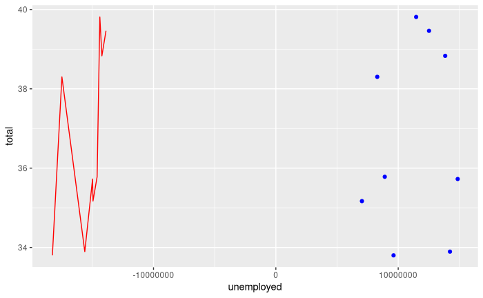

```r
ba_predict <- data.frame(ba_drug_predict=predict(corr_set1, ba_combined_dataset), ba_grad=ba_combined_dataset$total)
ggplot(data=ba_combined_dataset, aes(x=unemployed,y=total)) + geom_point(color='blue') + geom_line(color='red', data = ba_predict, aes(x=ba_drug_predict, y=ba_grad))
```

[figure not shown]

## Operationalization :

The best way we could follow through with this data is to increase the ability for individuals to pursue college, perhaps giving a stipend and making college subsidized by 15% of the countries military budget. We could have students commit to a year of community work in the area that they pursue their education in to get “returns” on the education if there is a push back.

After ten years, we would be able to see a generation who grew up from teenagers into adults without the pressure of having to apply for scholarships, or work during college and we could follow through with the amount of drug deaths (not use, because responsible use of stimulants or depressents have been a part of society forever and any prohibition of it has always failed) that follow the concurrent generations and address the educational benefits or the adjustment of further study to see what other confounding factors arise.